# third_package

이정우

2021년 3월 24일

# Chapter 1. 모델링을 위한 전처리

#### 문제 0 기본 세팅. tidyverse, data.table , gridExtra 를 부른 후 setwd로 'data.csv’ 및 'test.csv’ 가 있는 폴더로 경로를 설정하고, fread 로 data.csv’ 와 test.csv’ 를 불러오세요

```r
library("tidyverse")
library("data.table")
library("gridExtra")
library("catboost")
library("caret")
library("MLmetrics")
library("factoextra")
library("cluster")

setwd("C:/Users/10sop/Desktop/package/third_week")
data <- "data.csv" %>% fread
testset <- "test.csv" %>% fread
```

뒤 문제에서 쓸 패키지도 모두 불러왔습니다.

## [Train data(data.csv) 전처리 및 EDA]

#### 문제 1. 'bmi(bmi 지수)' 변수를 numeric 자료형으로 바꾸고, NA값을 mean imputation으로 채우세요.

```r
data$bmi <- data$bmi %>% as.numeric
bmi_mean <- data$bmi %>% mean(na.rm = TRUE)
data$bmi[data$bmi %>% is.na %>% which] <- bmi_mean
```

#### 문제 2. 문자형(chracter) 변수를 명목형 변수(factor)로 바꾸세요.

```r
data <- data %>% mutate_if(is.character, .funs = "as.factor")
```

#### 문제 3. 'id' 변수를 제거하세요.

```r
data <- data[, -'id']
```

#### 문제 4. 타겟(stroke) 값 별로 범주형 변수의 분포를 다음같이 시각화 하고, 간단해 해석해보세요.(gather, gridExtra 패키지 내 함수 이용).

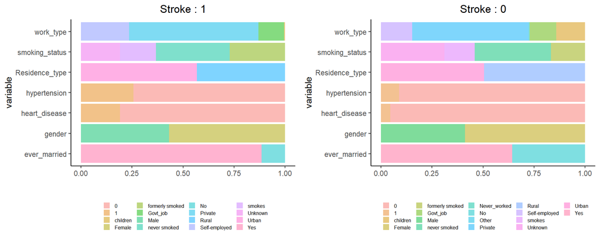

```r
data$hypertension <- data$hypertension %>% as.factor
data$heart_disease <- data$heart_disease %>% as.factor
data$stroke <- data$stroke %>% as.factor

factor_var <- names(data)[which(data %>% lapply(is.factor) %>% as.data.frame == TRUE)]
factor_col <- select(data, factor_var)

gather_stroke <- gather(factor_col %>% mutate_all(as.character),
                        key = 'key',
                        value = 'value',
                        -stroke)

stroke0_frame <- filter(gather_stroke, stroke == 0)
stroke0_frame[,'value'] <- stroke0_frame[,'value'] %>% as.factor
stroke1_frame <- filter(gather_stroke, stroke == 1)
stroke1_frame[, 'value'] <- stroke1_frame[, 'value'] %>% as.factor

factor_g0 <- ggplot(data = stroke0_frame,
            aes(x = key, fill = value)) +
  theme_classic()+
  geom_bar(position = 'fill',
           alpha = 0.5) +
  theme(legend.position = "bottom",
        legend.title = element_blank(),
        legend.text = element_text(size = 6),
        plot.title = element_text(hjust = 0.5))+
  guides(fill = guide_legend(keywidth = .6, keyheight = .6))+
  coord_flip() +
  labs(title = "Stroke : 0",
       x = "variable",
       y = "")

factor_g1 <- ggplot(data = stroke1_frame,
             aes(x = key, fill = value)) +
  theme_classic()+
  geom_bar(position = 'fill',
           alpha = 0.5) +
  theme(legend.position = "bottom",
        legend.title = element_blank(),
        legend.text = element_text(size = 6),
        plot.title = element_text(hjust = 0.5))+
  guides(fill = guide_legend(keywidth = .6, keyheight = .6))+
  coord_flip() +
  labs(title = "Stroke : 1",
       x = "variable",
       y = "")

grid.arrange(factor_g1, factor_g0, ncol = 2)
```

#### 문제 5. 타겟(stroke)별 별로 수치형 변수의 분포를 다음같이 시각화 하고,간단히 해석해보세요.(gather, gridExtra 패키지 내 함수 이용)

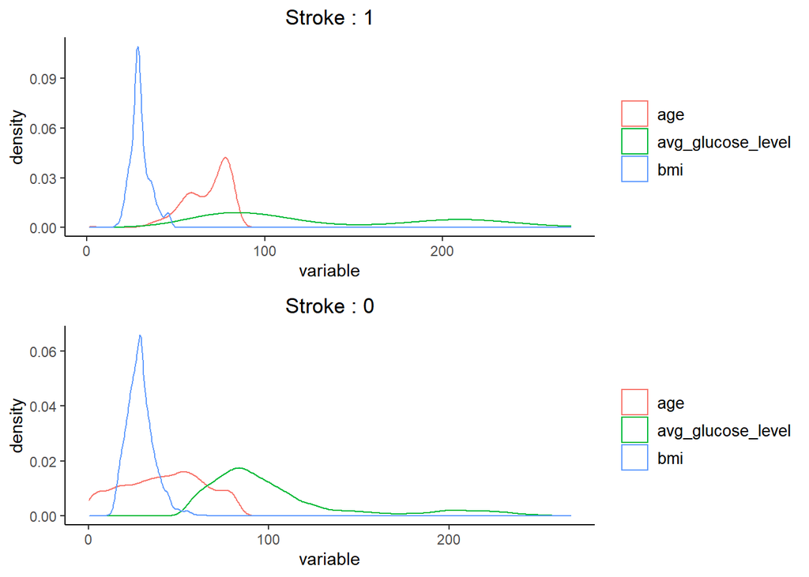

```r
numeric_var <- names(data)[which(data %>%lapply(is.numeric) %>% as.data.frame == TRUE)]
numeric_col <- select(data, numeric_var, stroke)
num_gather_stroke <- gather(numeric_col,
                            key = 'key',
                            value = 'value',
                            -stroke)


stroke0_num <- num_gather_stroke %>% filter( stroke == 0)
stroke0_num[,'value'] <- stroke0_num[,'value']
stroke1_num <- num_gather_stroke %>% filter(stroke == 1)
stroke1_num[, 'value'] <- stroke1_num[, 'value']


numeric_g1 <- ggplot(data = stroke1_num,
                     aes(x = value,
                         color = key,
                         group = key)) +
  theme_classic()+
  geom_density(position = 'identity',
               alpha = 0.7) +
  theme(legend.title = element_blank(),
        legend.text = element_text(size = 10),
        plot.title = element_text(hjust = 0.5))+
  guides(fill = guide_legend(keywidth = 5, keyheight = 5))+
  labs(title = "Stroke : 1",
       x = "variable",
       y = "density")

numeric_g0 <- ggplot(data = stroke0_num,
                     aes(x = value,
                         color = key,
                         group = key)) +
  theme_classic()+
  geom_density(position = "identity",
               alpha = 0.7) +
  theme(legend.title = element_blank(),
        legend.text = element_text(size = 10),
        plot.title = element_text(hjust = 0.5))+
  guides(fill = guide_legend(keywidth = 5, keyheight = 5))+
  labs(title = "Stroke : 0",
       x = "variable",
       y = "density")


grid.arrange(numeric_g1, numeric_g0, nrow= 2)
```

#### 문제 6. 타겟 변수와 범주형 변수에 대한 카이스퀘어 독립성 검정을 진행하고 다음과 같이 출력하세요.

```r
factor_var2 <- factor_var[factor_var != 'stroke']
chisq_test_result <- expand.grid(cate_var = factor_var2, chi = NA)

chisq_table <- table(factor_col[, 'gender']%>% as.matrix, factor_col$stroke )


for (i in factor_var2) {
  chisq_table <- table(factor_col[, i, with = F]%>% as.matrix, factor_col$stroke )
  if (chisq.test(chisq_table)$p.value <0.05) {
    chisq_test_result[which(chisq_test_result[,'cate_var'] == i), 'chi'] <- "denied"
  } else {
    chisq_test_result[which(chisq_test_result[,'cate_var'] == i), 'chi'] <- "accept"
  }
}
chisq_test_result
```

```
##         cate_var    chi
## 1         gender accept
## 2   hypertension denied
## 3  heart_disease denied
## 4   ever_married denied
## 5      work_type denied
## 6 Residence_type accept
## 7 smoking_status denied
```

#### 문제 7. 카이스퀘어 독립성 검정에서 가설을 기각하지 못한 범주형 변수를 제거하세요.

```r
meaningful_var <- filter(chisq_test_result, chi == "denied")[, 'cate_var']
data <- data %>% select(-meaningful_var)
```

## [Test data(test.csv) 전처리]

#### 문제 8. train data에서 했던 전처리 방법들을 사용하여 전처리 하세요.

```r
# bmi 변수의 자료형 바꾸고 mean imputation
testset$bmi <- testset$bmi %>% as.numeric
test_bmi_mean <- testset$bmi %>% mean(na.rm = TRUE)
testset$bmi[testset$bmi %>% is.na %>% which] <- bmi_mean

# 문자형 변수 자료형 바꾸기 & 자료형이 factor 여야 하는 변수 factor화 시키기.
testset <- testset %>% mutate_if(is.character, .funs = "as.factor")
testset$hypertension <- testset$hypertension %>% as.factor
testset$heart_disease <- testset$heart_disease %>% as.factor
testset$stroke <- testset$stroke %>% as.factor

# id 및 train 데이터에서 제거된 범주형 변수 제거하기
testset <- testset %>% select(-c('id', meaningful_var))
```

# Chapter 2. Catboost

#### 문제 0. Catboost 모델의 특성 및 대표적인 파라미터에 대해 간단히 설명하세요.

Catboost 모델은 ordering-principle 개념을 도입해서 기존의 boosting 방법의 데이터 누수를 해결한 모델이며, 범주형 변수가 많은 데이터셋에서 예측 성능이 뛰어나다는 특징이 있습니다. 대표적인 파라미터에는 나무 개수, 나무 깊이, learning rate 등이 있다.

#### 문제 1. expand.grid를 사용하여 다음과 같은 데이터 프레임을 만드세요.

```r
logloss_cb <- expand.grid(depth = c(4,6,8),
                          iterations = c(100, 200),
                          logloss = NA)
logloss_cb
```

```
##   depth iterations logloss
## 1     4        100      NA
## 2     6        100      NA
## 3     8        100      NA
## 4     4        200      NA
## 5     6        200      NA
## 6     8        200      NA
```

#### 문제 2. Catboost에 대해 depth와 iteration 파라미터 튜닝을 위한 grid search 5-fold CV를 진행하세요.

```r
set.seed(1234)

train_x_data <- data %>% select(-stroke)
train_y_data <- data$stroke %>% as.matrix %>% as.integer
test_x_data <- testset %>% select(-stroke)
test_y_data <- testset$stroke %>% as.matrix %>% as.integer

CV_fold <- createFolds(1:nrow(train_x_data), 5,
                     list = TRUE, returnTrain = FALSE)

pred <- NULL
CV_logloss <- NULL

start_time <- Sys.time()
for (k in 1: length(logloss_cb[,'depth'])) {
  paras <- list(depth = logloss_cb[k, 'depth'],
                iterations = logloss_cb[k, 'iterations'],
                loss_function = 'Logloss',
              random_seed = 1234)
  for (i in 1: length(CV_fold)) {

    CV_train_x <- train_x_data[-CV_fold[[i]]]
    CV_train_y <- train_y_data[-CV_fold[[i]]] %>% as.matrix %>% as.integer
    CV_test_x <- train_x_data[CV_fold[[i]]]
    CV_test_y <- train_y_data[CV_fold[[i]]] %>% as.matrix %>% as.integer

    CV_train_pool <- catboost.load_pool(data = CV_train_x,
                                        label = CV_train_y)
    CV_test_pool <- catboost.load_pool(data = CV_test_x,
                                       label = CV_test_y)

    catboost_model <- catboost.train(CV_train_pool,
                                     params = paras)
    CV_pred <- catboost.predict(catboost_model, CV_test_pool,
                                prediction_type = 'Probability')
    CV_logloss <- c(CV_logloss, LogLoss(CV_pred, CV_test_y))
  }
  logloss_cb[k, 'logloss'] <- CV_logloss %>% mean
}
```

[output not shown]

[output cut: 4515 more lines]

```r
end_time <- Sys.time()
logloss_cb
```

```
##   depth iterations   logloss
## 1     4        100 0.1591362
## 2     6        100 0.1597225
## 3     8        100 0.1601641
## 4     4        200 0.1602632
## 5     6        200 0.1614963
## 6     8        200 0.1633210
```

```r
# 걸린 시간
end_time - start_time
```

```
## Time difference of 1.864338 mins
```

#### 문제 3. logloss_cb에서 가장 낮은 logloss 값의 행을 출력하세요.

```r
min_logloss <- filter(logloss_cb,
                      logloss_cb[, 'logloss'] %>% min == logloss_cb[, 'logloss'] )
min_logloss
```

```
##   depth iterations   logloss
## 1     4        100 0.1591362
```

#### 문제 4. 가장 낮은 logloss 값의 파라미터로 전체 데이터를 학습시켜 test set에 대한 logloss값을 구하세요.

```r
paras <- list(depth = min_logloss[1, 'depth'],
              iterations = min_logloss[1, 'iterations'],
              loss_function = 'Logloss',
              random_seed = 1234)


train_pool <- catboost.load_pool(data = train_x_data,
                                 label = train_y_data)
test_pool <- catboost.load_pool(data = test_x_data,
                                label = test_y_data)

catboost_model <- catboost.train(train_pool,
                                 params = paras)
```

[output not shown]

[output cut: 86 more lines]

```r
pred <- catboost.predict(catboost_model, test_pool,
                         prediction_type = 'Probability')
test_logloss <- LogLoss(pred, test_y_data)
test_logloss
```

```
## [1] 0.1592684
```

# Chaper 3. K-means Clustering

#### 문제 1. 수치형 변수에 대해 scale 함수로 정규화 스케일링을 하세요.

```r
numeric_data <- numeric_col[, -'stroke']
scale_num_data <- numeric_data %>% scale %>% as.data.frame
```

#### 문제 2. fviz_nbclust 함수로 다음과 같이 시각화 한 뒤, 적절한 K값이 무엇인지 설명하세요.

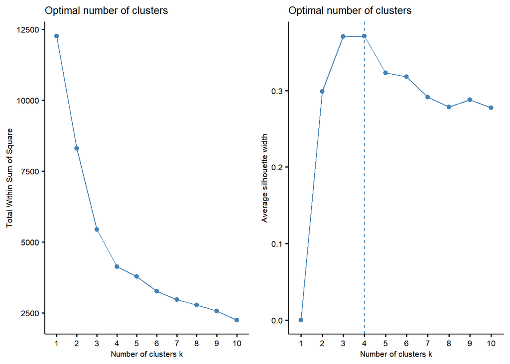

```r
elbow_method <- fviz_nbclust(scale_num_data,
                             kmeans,
                             method = "wss") +
  theme(plot.title = element_text(hjust = 0, size = 10),
        axis.title = element_text(size = 8),
        axis.text = element_text(size = 8))

silhouette_method <- fviz_nbclust(scale_num_data, kmeans, method = "silhouette") +
  theme(plot.title = element_text(hjust = 0, size = 10),
        axis.title = element_text(size = 8),
        axis.text = element_text(size = 8))

grid.arrange(elbow_method, silhouette_method, ncol= 2)
```

왼쪽 그래프는 wss 방법(elbow 방법)을 적용한 그래프로, 그래프의 팔꿈치 모양으로 꺾이는 곳의 k값을 최적의 cluster 개수로 하는 방법입니다. 오른쪽 그래프는silhouette 방법을 적용한 그래프로, 값이 가장 큰 k 개수를 최적의 cluster 개수로 하는 방법입니다. 그래프를 보면, k=4를 최적의 cluster 개수임을 알 수 있습니다.

#### 문제 3. K-means 클러스터링을 한 후, 다음과 같이 시각화하세요

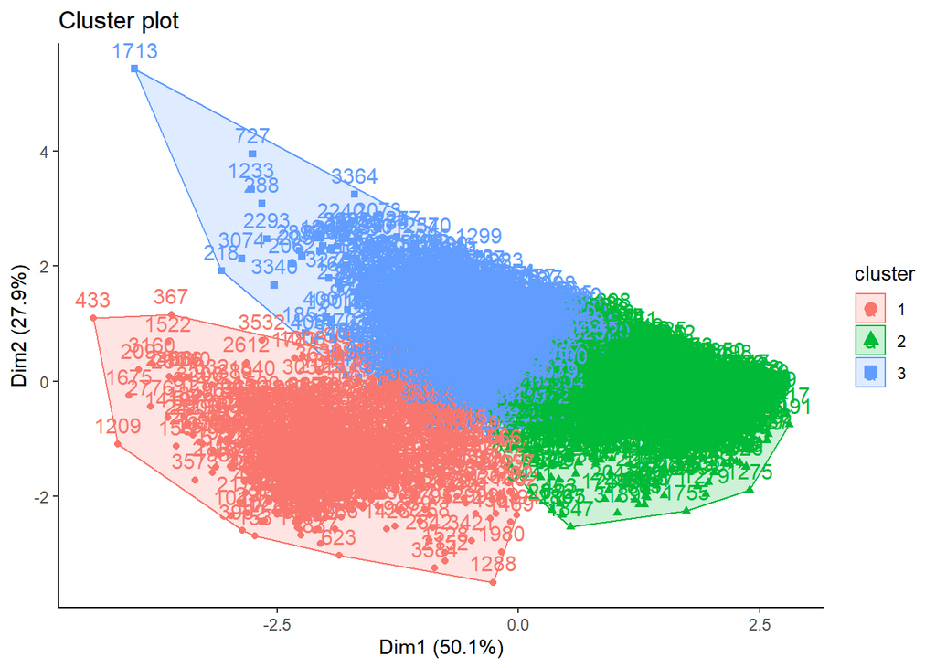

```r
set.seed(1234)
km_cluster <- kmeans(scale_num_data , 3, nstart = 1, iter.max = 30)
km_cluster$cluster <- as.factor(km_cluster$cluster)

fviz_cluster(km_cluster, data = scale_num_data) +
  theme_classic()
```

문제와는 다르게 클러스터 번호는 다르게 지정됐지만 제대로 클러스터가 된 모습입니다.

#### 문제 4. 사용한 변수인 age, avg_glucose_level(평균 혈당)),bmi( bmi 수치에 대해 다음과 같이 box_plot 시각화를 하고 클러스터 별로 해석해보세요.

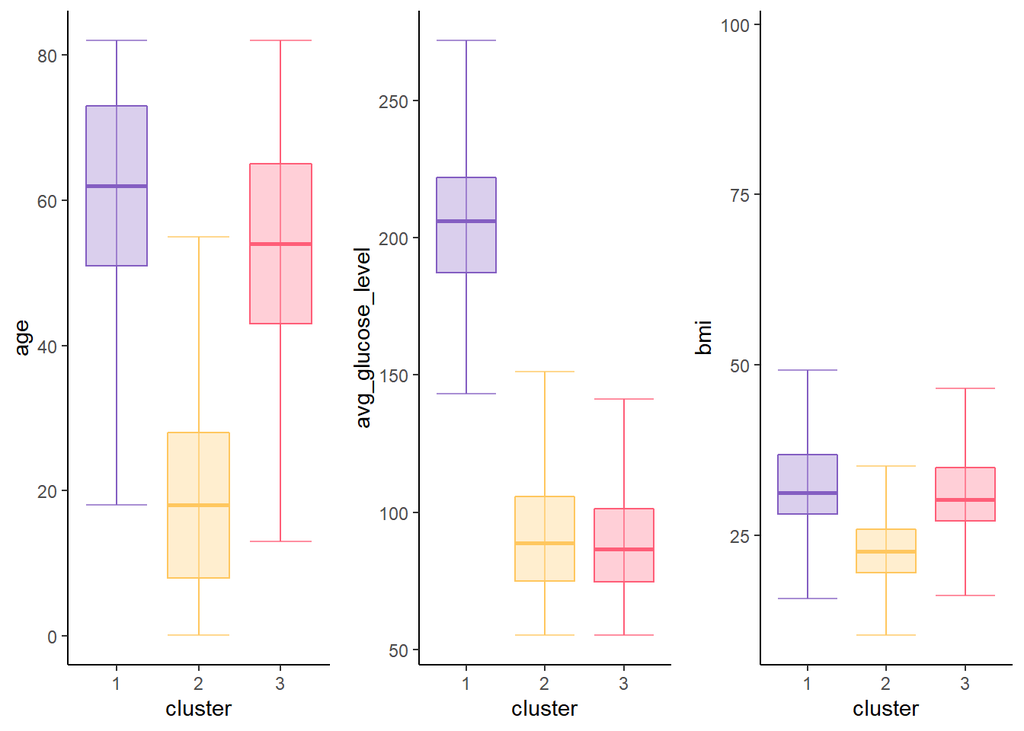

```r
cluster_data <- numeric_data %>% mutate(cluster = km_cluster$cluster)

age_gg <- ggplot(data = cluster_data,
                 aes(x = cluster,
                 y = age,
                 group = cluster)) +
  geom_boxplot(fill = c("#845ec2", "#ffc75f", "#ff5e78"),
               alpha = 0.3,
               colour =  c("#845ec2", "#ffc75f", "#ff5e78"),
               outlier.shape = NA)+
  stat_boxplot(geom = "errorbar",
               colour = c("#845ec2", "#ffc75f", "#ff5e78"),
               alpha = 0.7)+
  theme_classic()

glucose_gg <- ggplot(data = cluster_data,
                     aes(x = cluster,
                         y = avg_glucose_level,
                         group = cluster)) +
  geom_boxplot(fill = c("#845ec2", "#ffc75f", "#ff5e78"),
               alpha = 0.3,
               colour =  c("#845ec2", "#ffc75f", "#ff5e78"),
               outlier.shape = NA)+
  stat_boxplot(geom = "errorbar",
               colour = c("#845ec2", "#ffc75f", "#ff5e78"),
               alpha = 0.7)+
  theme_classic()

bmi_gg <- ggplot(data = cluster_data,
                 aes(x = cluster,
                     y = bmi,
                     group = cluster)) +
  geom_boxplot(fill = c("#845ec2", "#ffc75f", "#ff5e78"),
               alpha = 0.3,
               colour =  c("#845ec2", "#ffc75f", "#ff5e78"),
               outlier.shape = NA)+
  stat_boxplot(geom = "errorbar",
               colour = c("#845ec2", "#ffc75f", "#ff5e78"),
               alpha = 0.7)+
  theme_classic()


grid.arrange(age_gg, glucose_gg, bmi_gg, ncol = 3)
```

클러스터 번호가 문제와는 다르게 붙어서 문제에 나온 box plot과 위치는 다르지만 위치 말고 box plot 자체는 문제와 똑같이 표현되었습니다.